# Reproducible Research: Peer Assessment 1

## Imputing missing values

Find out the rows with missing values

```r
   naVector <- is.na(data$steps)
   nullData <- data[naVector,]
   nrow(nullData)
```

```
## [1] 2304
```

Now fill the missing fields with the mean of the corresponding interval. i.E the value in the row of interval 0 will be filled with the mean of all steps in the interval 0.

```r
   f <- merge(data, intervalSteps, by="interval", all = TRUE)
   f$steps <- ifelse(is.na(f$steps.x), f$steps.y, f$steps.x)
   newData <- f[,c(1,3,5)]
```

Show the histogram, mean and median with the missing values filled.

```r
   newStepsPerDay <- aggregate(steps ~ date, newData, sum)
   newStepsPerDay
```

```
##          date    steps
## 1  2012-10-01 10766.19
## 2  2012-10-02   126.00
## 3  2012-10-03 11352.00
## 4  2012-10-04 12116.00
## 5  2012-10-05 13294.00
## 6  2012-10-06 15420.00
## 7  2012-10-07 11015.00
## 8  2012-10-08 10766.19
## 9  2012-10-09 12811.00
## 10 2012-10-10  9900.00
## 11 2012-10-11 10304.00
## 12 2012-10-12 17382.00
## 13 2012-10-13 12426.00
## 14 2012-10-14 15098.00
```

[output cut: 47 more lines]

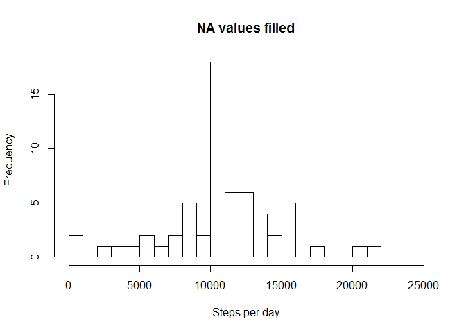

```r
   hist(newStepsPerDay$steps, breaks=20, xlim=c(0,25000), xlab="Steps per day", main="NA values filled")
```

```r
   mean(newStepsPerDay$steps)
```

```
## [1] 10766.19
```

```r
   median(newStepsPerDay$steps)
```

```
## [1] 10766.19
```

There are no substantial difference between the histograms with and without the NA values

## Are there differences in activity patterns between weekdays and weekends?

Use the library “lubridate” instead of weekdays() to get rid of the names in the locale in use.

```r
   #install.packages("lubridate")
   library(lubridate)
```

Add a factor variable in the dataset indicating whether a given date is a weekday or weekend day.

```r
   newData$day <- ifelse(wday(newData$date) == 1, "weekend",
                  ifelse(wday(newData$date) == 7, "weekend", "weekday"))

   newData$day <- as.factor(newData$day)
```

Calculate the mean for the weekend and the weekdays

```r
   weekEnd <- aggregate(steps ~ interval, newData[newData$day == "weekend",], mean)
   weekDay <- aggregate(steps ~ interval, newData[newData$day == "weekday",], mean)
```

Show the two plots.

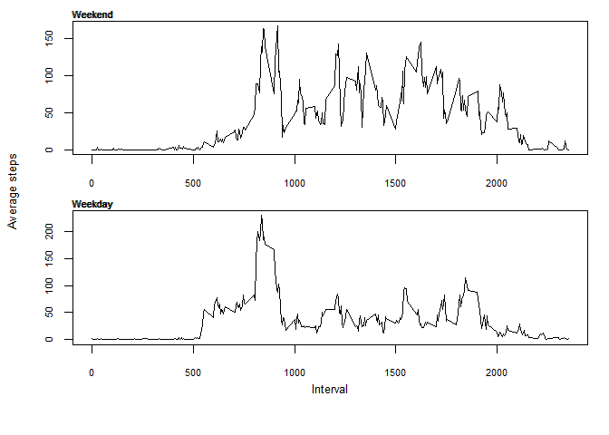

```r
   par(mfrow = c(2,1), cex.axis=0.7,
          oma = c(3,4,0,0) + 0.1,
          mar = c(2,0,1,1) + 0.1)
   plot(weekEnd$interval, weekEnd$steps, type="l", ylab="", xlab="")
   mtext("Weekend", at= c(6,5), cex=0.7)

   plot(weekDay$interval, weekDay$steps, type="l", ylab="", xlab="")
   mtext("Weekday", at= c(6,5), cex=0.7)

   mtext("Interval", side=1, line = 2, cex=0.8)
   title(ylab = "Average steps", cex.lab=0.8, outer = TRUE)
```